# Exploratory Data Analysis On Wine Quality

### Plot Two

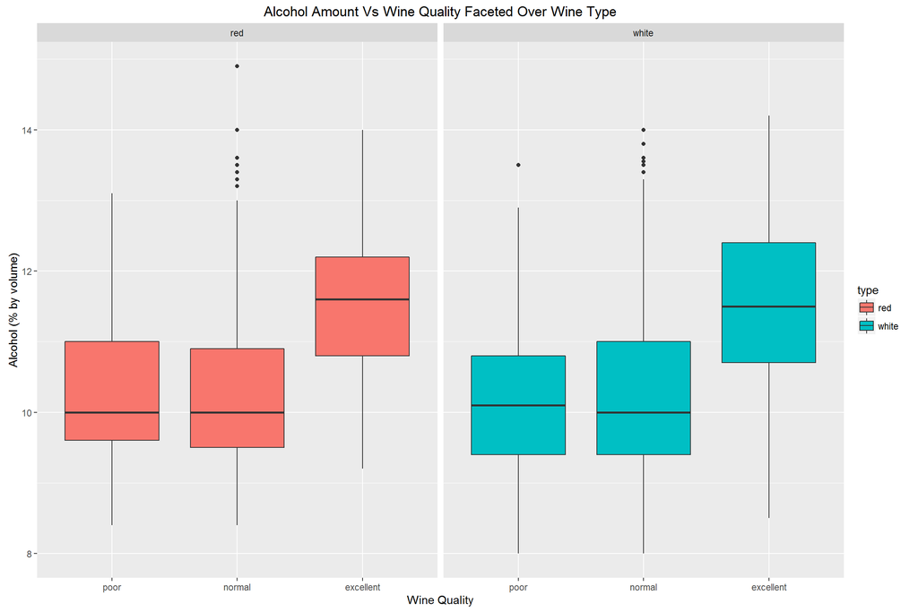

```
## Source: local data frame [6 x 6]
## Groups: type [?]
##
##     type bucket.quality median.amount   iqr mean.amount       std
##   (fctr)         (fctr)         (dbl) (dbl)       (dbl)     (dbl)
## 1    red           poor          10.0   1.4    10.21587 0.9181778
## 2    red         normal          10.0   1.4    10.25272 0.9723537
## 3    red      excellent          11.6   1.4    11.51805 0.9981532
## 4  white           poor          10.1   1.4    10.17350 1.0275704
## 5  white         normal          10.0   1.6    10.26981 1.1040355
## 6  white      excellent          11.5   1.7    11.41602 1.2552094
```

```
##
##  Pearson's product-moment correlation
##
## data:  quality and alcohol
## t = 39.97, df = 6495, p-value < 2.2e-16
## alternative hypothesis: true correlation is not equal to 0
## 95 percent confidence interval:
##  0.4245892 0.4636261
## sample estimates:
##       cor
## 0.4443185
```

### Description Two

The reason I selected this plot is to show that alcohol amount being the special attribute among all the others. First, it had the highest positive correlation with the wine quality than any other attribute. Second, when I plotted wine attributes against bucket.quality, I observed excellent wines had considerably higher median amounts of alcohol, 11.5%, compared to poor and normal quality wines which had about 10%, and that when observed on the above boxplots created a nice separation among excellent and the rest and that pattern irrespective of wine type. This suggested to me that alcohol amount is an important feature to consider in building up the model at later stage. All I need to do is find another attribute that would make a good separation among all of them and that was my focus in multivariate plots.

### Plot Three

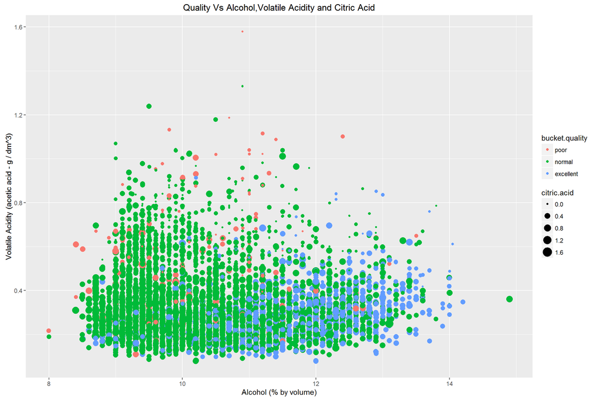

### Description Three

At this stage I am looking to create an ocean among wine qualities, by adding few other attributes besides the alcohol amount, which as I mentioned above, is important classifying attribute. Volatile acidity came as second potential attribute as poor wines had larger median amounts of volatile acidity and it had second strongest correlation with quality, after mentioning in the above analysis for keeping density out. Thus with this intuition, I tried the above plot, but it did not produce clear boundry separating the wine qualities of poor, normal and excellent. There was a lot of mixing between each class. I also added citric acid, because excellent wines had large amounts of it and poor with really little. But the result was the same. This also shows the reason why my knn classifier is performing only at 78% accuracy when I chose volatile acidity and alcohol amount as the only predictors. In addition, it also tells the importance of the variables I have narrowed down in this plot, because when I chose all of the attributes in the data set, it gave slightly better result with KNN classifier, roughly 79% accuracy. In addition, this plot tells that it is easier to separate between poor and excellent wines.

Furthermore, few important things repeat in this plot too. First, excellent quality wines have higher alcohol amounts, less volatile acidity and higher citric acid concentration compared to poor class. In additions, normal class is quite spread out, and in large amount, and blends with poor and excellent quality wines. Furthermore, poor rated wines have lower alcohol amounts, higher volatile acidity and less citric acid concentrations.

# Reflections

As my main goal was to explore the data set in view of building a wine quality classifier, I was slightly able to improve compared to just marking all the wines as normal, which I consider my success. However, my features selected after EDA were not much rich. I tried several multivariate plots in order to find a good separation between wine qualities, but I failed to do that, as there were huge mixes among each quality class. However, I think, if I had more attributes available, for instance, wine price, brand ratings, maunfactoring information etc, I would have been able to construct a better classifier. Second, I think, the data set must have more representative wines of poor and excellent qualities, and with this constraint accompanying several other attribues,I would like to improve the classifying task further. Right now, I can build a good wine type classifier with this data set. For my future work, I would like to perform EDA on much richer and representative data set, that include wines from whole lot of other countries not just Portuguese “Vinho Verde” wine. Plus,I have just used K-nearest-neighbor classifier, which according to some people,usually gets the job done. Exploring other models like logistic regression, LDA, QDA and famous support vector machines, would definitely improve on the task with much richer and complete data set.

In conclusion, using exploratory data analysis, I was able to see new relations, confirm the patterns already stated in the data set description, and reduce the number of features required in classification.